# Chapter 2

## Conceptual

**Variance**: variance refers to the amount by which would change if we take different dataset.

**Bias**: bias refers to the error that is introduced by approximating a real-life problem, which may be extremely complicated, by a much simpler model. (i.e., whether the parameters are considered sufficiently to model the real-world problem.)

As a general rule, as we use more flexible methods, the variance will increase and bias will decrease.

### Excercise 1a

Better: When n is great, p is small, the model has low variance and high bias, therefore using more flexible method is more suitable. Small number of p will underfit large number of observations.

### Excercise 1b

Worse: When n is small, p is great, the model has high variance and low bias, therefore using more inflexible method is more suitable. Large number of p will overfit small number of observations.

### Excercise 1c

Better: The relationship between the predicators and response is highly non-linear, meaning we need more parameters to fit the data, i.e., to use a more flexible method.

### Excercise 1d

Nothing change: since variance of the error term indicate irreducible error.

### Excercise 2a

Regression: CEO salary is quantitative.  
Inference: we are only interested in determining which factor(s) affect CEO salary.  
$n = 500$, $p = 3$.

### Excercise 2b

Classification: success or failure is qualitative.  
Prediction: we are interested to know whether it will be successful or not.  
$n = 20$, $p = 13$.

### Excercise 2c

Regression: % change is quantitative.  
Prediction: we are interested in predicting % change.  
$n = 52$, $p = 3$.

### Excercise 3

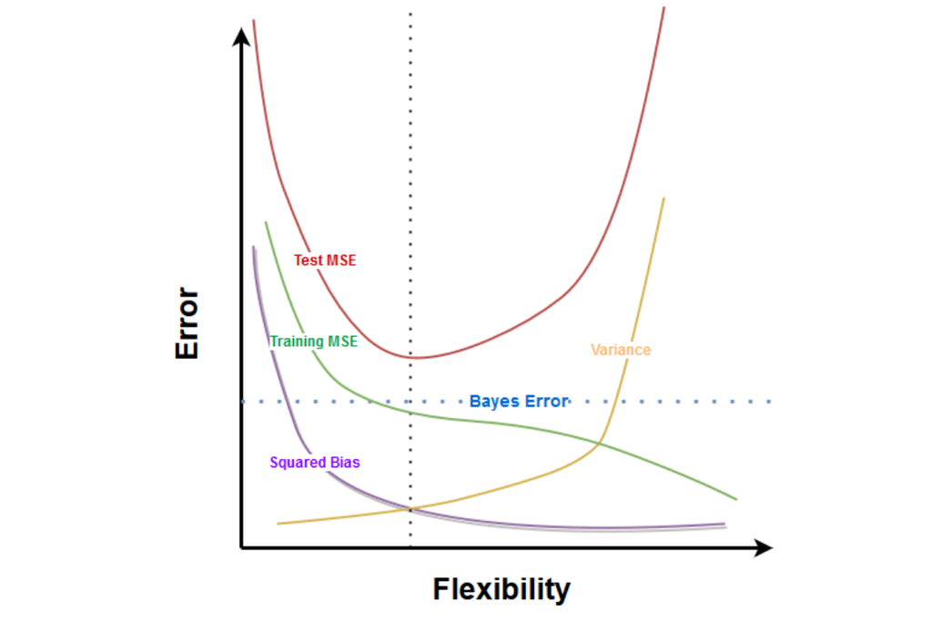

### Excercise 4a

To predict whether next product online will be successful or not, provided that price charged for the product, marketing budget, and competition prices. The goal is for prediction.

To predict whether the patches extracted from an image contains a pedestrian, provided the raw image. The goal is for prediction.

To tell which factors(s) are related to duration of users, given the color scheme of websites, number of text, ranking of page, search engine used, etc.

To predict whether there will be eddies around island, provided all the climate data last month. The goal is for prediction.

### Excercise 4b

To predict % change of stock return next week, given all the history of previous years. The goal is for prediction.

To predict precipitation for next month, given all the precipitation data of each month in last ten years.

To tell which factor(s) affect most on crime phenomena (% increase in crime records), whether it is low society welfare, low incoming of criminals, high intensity drug trafficking etc. The goal is for inference.

### Excercise 4c

Clustering location based on sales of used cars to decide which zone should be invested to a greater extent.

Clustering text to help us decide categories of the given articles.

Given all quantitative sizes, corresponding marketing of shirts, deciding whether we need to have a rougher measurements to sell (like X/M/L).

### Excercise 5

Advantages of using a very flexible method for regression or classification is that the parameters will better fit the training set which results in low bias, however, if the data itself is linear, more flexible method will easily overfit the data, i.e., resulting in high variance.

If the data (real-life problem) is highly non-linear (complicated), then a more flexible approach should be preferred. Otherwise, if the data is linear (simple), then a less flexible approach should be chosen.

### Excercise 6

Parametric approaches make an assumption about the function form, or shape of $f$, while non-parametric approaches makes no such assumption. Instead, non-parametric methods seek an estimate of f that gets as close to the data points as possible without being too rough or wiggly.

Using parametric approaches simplify the problem down to one of estimating a set of parameters which will be generally much easier to estimate. The disadvantages of it is that usually the model we choose does not match the true unknown form of $f$. In cases of estimated function form is different (even far) from the true $f$, non-parametric methods completely avoid the danger since essentially there is no assumption is made about the form of $f$. But non-parametric approaches require a large amount of observations (far more than is typically needed for a parametric approach) to obtain an accurate estimate of $f$.

### Excercise 7a

| Obs. NO. | $X_1$ | $X_2$ | $X_3$ | $Y$ | $d(X_i,X_0)$ |
| --- | --- | --- | --- | --- | --- |
| 0 | 0 | 0 | 0 |  | 0 |
| 1 | 0 | 3 | 0 | Red | 3 |
| 2 | 2 | 0 | 0 | Red | 2 |
| 3 | 0 | 1 | 3 | Red | $\sqrt {10}$ |
| 4 | 0 | 1 | 2 | Green | $\sqrt 5$ |
| 5 | -1 | 0 | 1 | Green | $\sqrt 2$ |
| 6 | 1 | 1 | 1 | Red | $\sqrt 3$ |

### Excercise 7b

When $K = 1$, the nearest point is observation NO. 5, which belongs to green. Therefore, we predict test point as green.

### Excercise 7c

When $K = 3$, the nearest three point are observation NO. 2, 5, 6, which belongs to red, green, red. $\Pr (Y = {\rm{Red}} |{\rm{X}} = {{\rm{X}}_0}) = \frac{2}{3}$, $\Pr (Y = {\rm{Green}} |{\rm{X}} = {{\rm{X}}_0}) = \frac{1}{3}$, therefore, we predict test point as red.

### Excercise 7b

We would expect $K$ to be small, because as $K$ decrease ($\frac{1}{K}$ increase), the flexibility increases as well. Since fitting a highly non-linear data requires a more flexible method, so we need $K$ to be small.

## Applied

### Excercise 8a

```r
library(ISLR)
college = College
# fix(college) -- not applicable in R markdown
```

### Excercise 8b

```r
# rownames(college) = college[, 1] -- dataset has been updated by removing column of names
# fix(college) -- not applicable in R markdown
```

### Excercise 8c

```r
summary(college)
```

```
##  Private        Apps           Accept          Enroll       Top10perc
##  No :212   Min.   :   81   Min.   :   72   Min.   :  35   Min.   : 1.00
##  Yes:565   1st Qu.:  776   1st Qu.:  604   1st Qu.: 242   1st Qu.:15.00
##            Median : 1558   Median : 1110   Median : 434   Median :23.00
##            Mean   : 3002   Mean   : 2019   Mean   : 780   Mean   :27.56
##            3rd Qu.: 3624   3rd Qu.: 2424   3rd Qu.: 902   3rd Qu.:35.00
##            Max.   :48094   Max.   :26330   Max.   :6392   Max.   :96.00
##    Top25perc      F.Undergrad     P.Undergrad         Outstate
##  Min.   :  9.0   Min.   :  139   Min.   :    1.0   Min.   : 2340
##  1st Qu.: 41.0   1st Qu.:  992   1st Qu.:   95.0   1st Qu.: 7320
##  Median : 54.0   Median : 1707   Median :  353.0   Median : 9990
##  Mean   : 55.8   Mean   : 3700   Mean   :  855.3   Mean   :10441
##  3rd Qu.: 69.0   3rd Qu.: 4005   3rd Qu.:  967.0   3rd Qu.:12925
##  Max.   :100.0   Max.   :31643   Max.   :21836.0   Max.   :21700
##    Room.Board       Books           Personal         PhD
##  Min.   :1780   Min.   :  96.0   Min.   : 250   Min.   :  8.00
##  1st Qu.:3597   1st Qu.: 470.0   1st Qu.: 850   1st Qu.: 62.00
##  Median :4200   Median : 500.0   Median :1200   Median : 75.00
##  Mean   :4358   Mean   : 549.4   Mean   :1341   Mean   : 72.66
##  3rd Qu.:5050   3rd Qu.: 600.0   3rd Qu.:1700   3rd Qu.: 85.00
##  Max.   :8124   Max.   :2340.0   Max.   :6800   Max.   :103.00
##     Terminal       S.F.Ratio      perc.alumni        Expend
##  Min.   : 24.0   Min.   : 2.50   Min.   : 0.00   Min.   : 3186
##  1st Qu.: 71.0   1st Qu.:11.50   1st Qu.:13.00   1st Qu.: 6751
##  Median : 82.0   Median :13.60   Median :21.00   Median : 8377
##  Mean   : 79.7   Mean   :14.09   Mean   :22.74   Mean   : 9660
##  3rd Qu.: 92.0   3rd Qu.:16.50   3rd Qu.:31.00   3rd Qu.:10830
##  Max.   :100.0   Max.   :39.80   Max.   :64.00   Max.   :56233
##    Grad.Rate
##  Min.   : 10.00
##  1st Qu.: 53.00
##  Median : 65.00
##  Mean   : 65.46
##  3rd Qu.: 78.00
##  Max.   :118.00
```

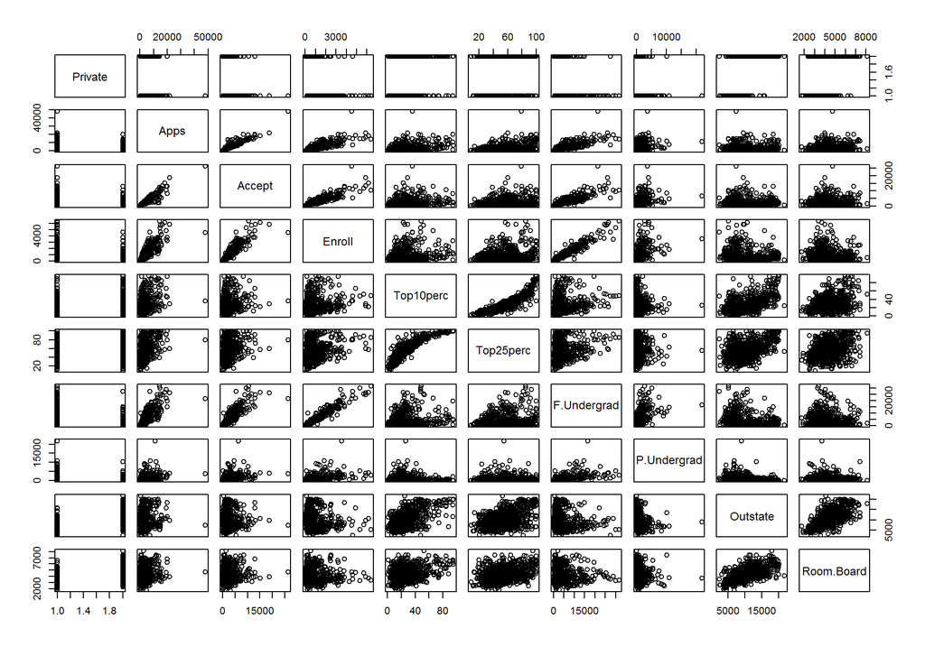

```r
pairs(college[, 1:10])
```

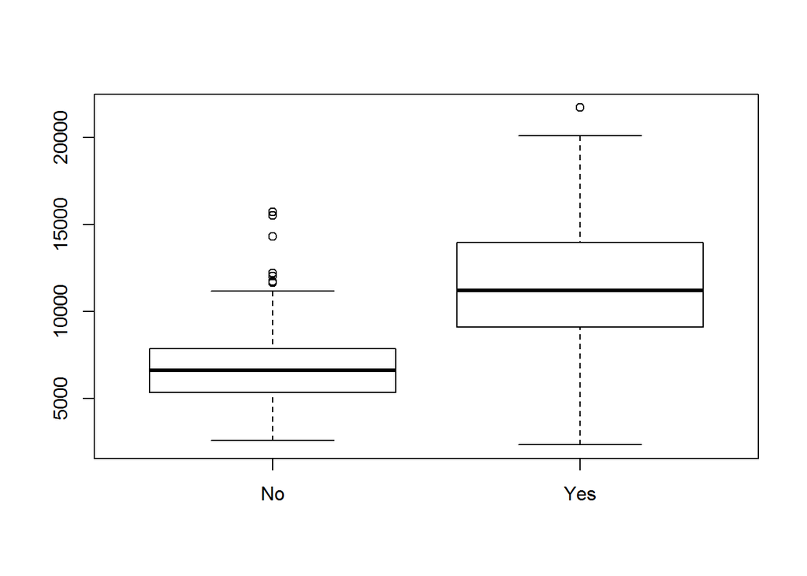

```r
plot(college$Private, college$Outstate)
```

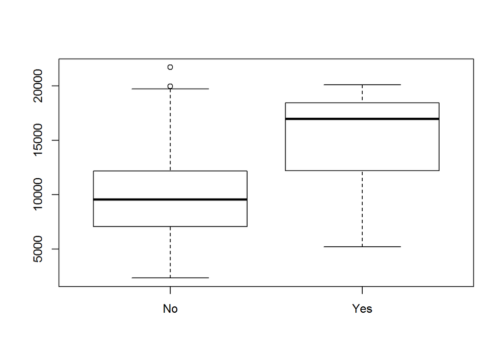

```r
Elite = rep("No", nrow(college))
Elite[college$Top10perc > 50] = "Yes"
Elite = as.factor(Elite)
college = data.frame(college, Elite)
plot(college$Elite, college$Outstate)
```

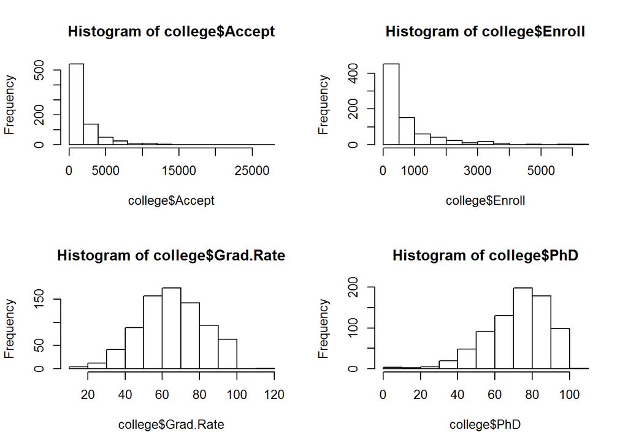

```r
par(mfrow=c(2,2))
hist(college$Accept)
hist(college$Enroll)
hist(college$Grad.Rate)
hist(college$PhD)
```

### Excercise 9a

```r
auto = Auto
summary(auto)
```

```
##       mpg          cylinders      displacement     horsepower
##  Min.   : 9.00   Min.   :3.000   Min.   : 68.0   Min.   : 46.0
##  1st Qu.:17.00   1st Qu.:4.000   1st Qu.:105.0   1st Qu.: 75.0
##  Median :22.75   Median :4.000   Median :151.0   Median : 93.5
##  Mean   :23.45   Mean   :5.472   Mean   :194.4   Mean   :104.5
##  3rd Qu.:29.00   3rd Qu.:8.000   3rd Qu.:275.8   3rd Qu.:126.0
##  Max.   :46.60   Max.   :8.000   Max.   :455.0   Max.   :230.0
##
##      weight      acceleration        year           origin
##  Min.   :1613   Min.   : 8.00   Min.   :70.00   Min.   :1.000
##  1st Qu.:2225   1st Qu.:13.78   1st Qu.:73.00   1st Qu.:1.000
##  Median :2804   Median :15.50   Median :76.00   Median :1.000
##  Mean   :2978   Mean   :15.54   Mean   :75.98   Mean   :1.577
##  3rd Qu.:3615   3rd Qu.:17.02   3rd Qu.:79.00   3rd Qu.:2.000
##  Max.   :5140   Max.   :24.80   Max.   :82.00   Max.   :3.000
##
##                  name
##  amc matador       :  5
##  ford pinto        :  5
##  toyota corolla    :  5
##  amc gremlin       :  4
##  amc hornet        :  4
##  chevrolet chevette:  4
##  (Other)           :365
```

### Excercise 9b

```r
range(auto$mpg)
```

```
## [1]  9.0 46.6
```

### Excercise 9c

```r
mean(auto$mpg)
```

```
## [1] 23.44592
```

```r
sd(auto$mpg) # sqrt(var(auto$mpg))
```

```
## [1] 7.805007
```

### Excercise 9d

```r
sub_auto = auto[-(10:85), ]
range(sub_auto$mpg)
```

```
## [1] 11.0 46.6
```

```r
mean(sub_auto$mpg)
```

```
## [1] 24.40443
```

```r
sd(sub_auto$mpg) # sqrt(var(sub_auto$mpg))
```

```
## [1] 7.867283
```

### Excercise 9e

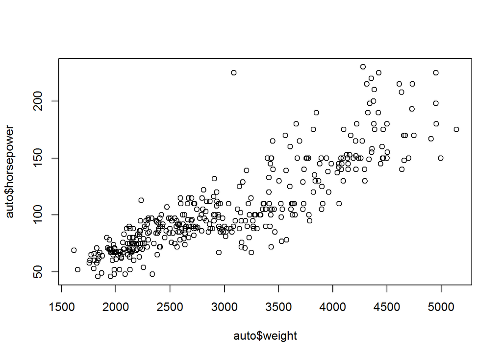

```r
# heavier car indicates more horsepower needed
plot(auto$weight, auto$horsepower)
```

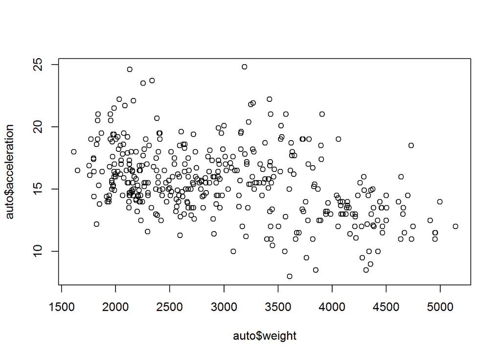

```r
# heavier car indicates less acceleration
plot(auto$weight, auto$acceleration)
```

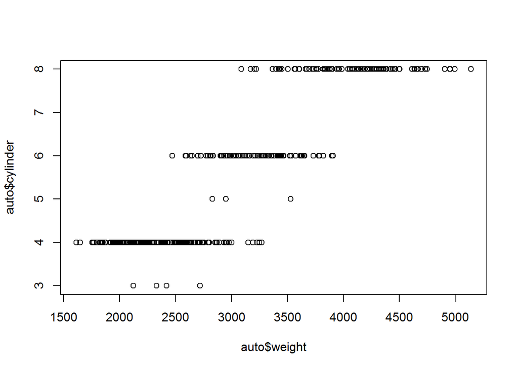

```r
# heavier car indicates more cylinders that may be configured
plot(auto$weight, auto$cylinder)
```

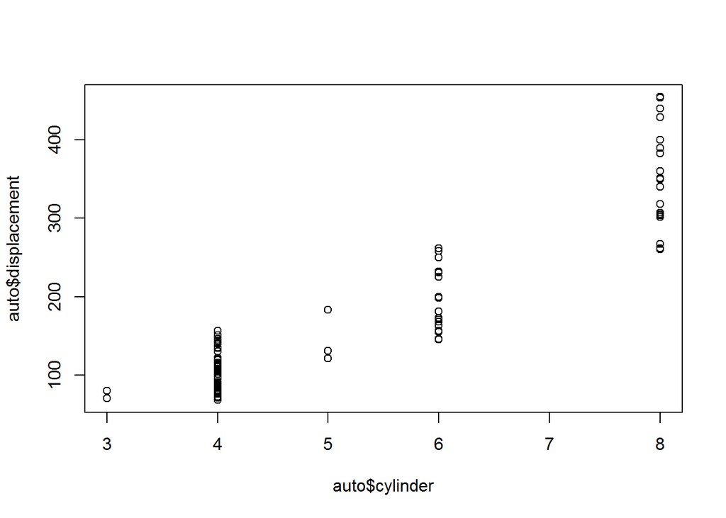

```r
# more cynlinders results in greater displacement
plot(auto$cylinder, auto$displacement)
```

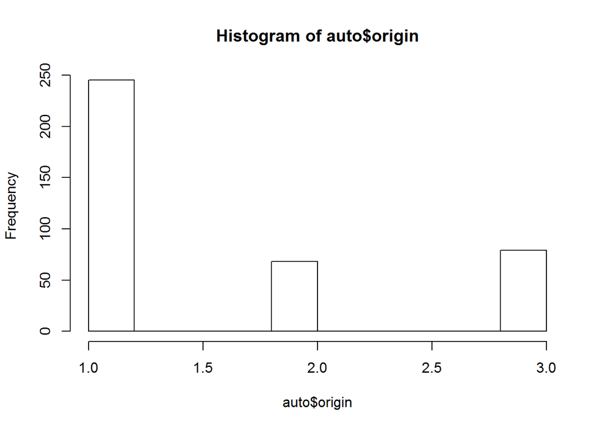

```r
# More American autos in the dataset
hist(auto$origin)
```

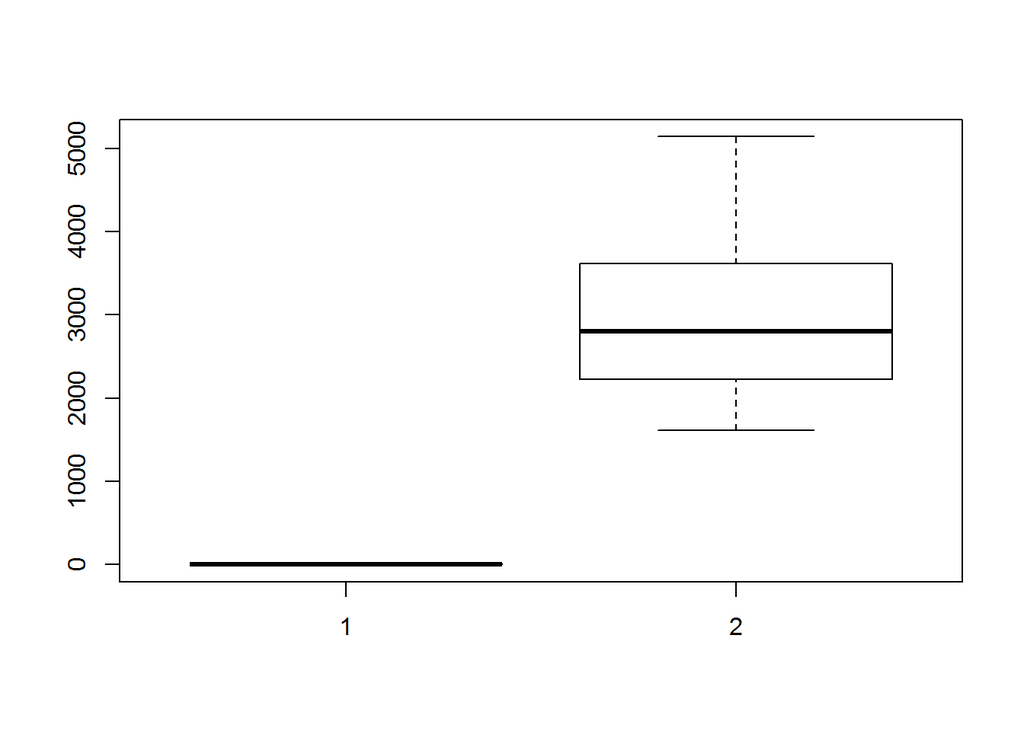

```r
boxplot(auto$origin, auto$weight)
```

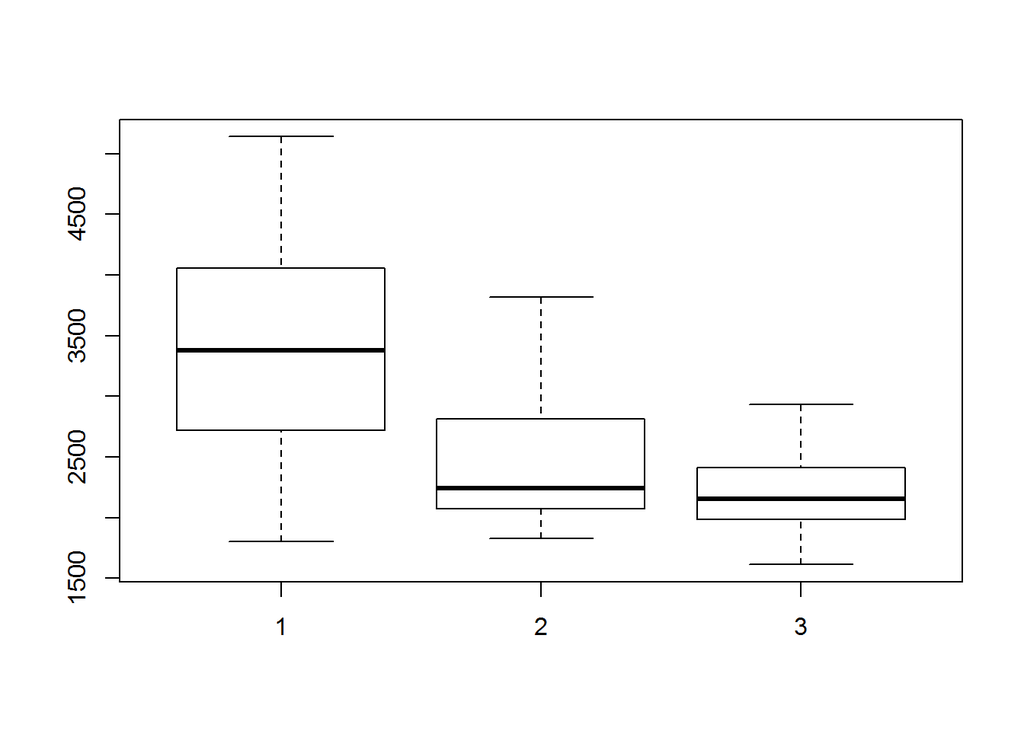

```r
# American cars are heavier, Japanese cars are lighter
boxplot(auto$weight~ auto$origin)
```

### Excercise 9f

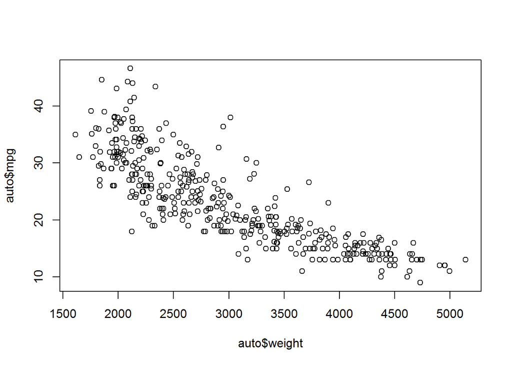

```r
plot(auto$weight, auto$mpg)
```

Heavier car indicates less mpg.

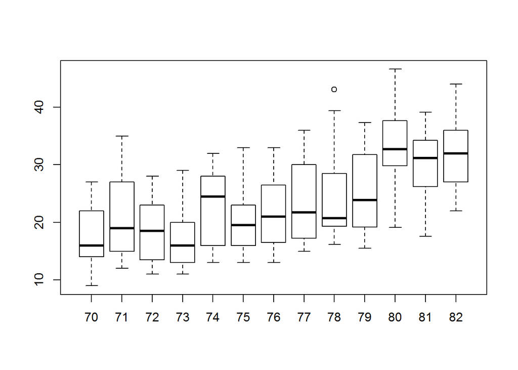

```r
boxplot(auto$mpg~ auto$year)
```

Older cars indicate less mpg.

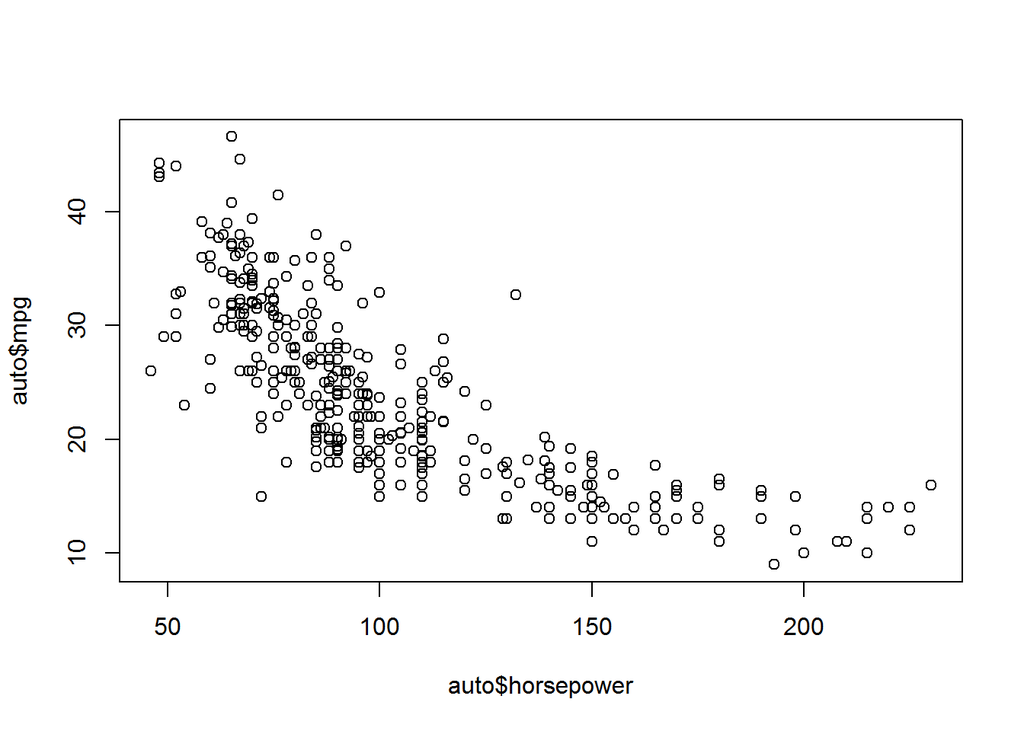

```r
plot(auto$horsepower, auto$mpg)
```

Less horsepower indicate higher mpg.

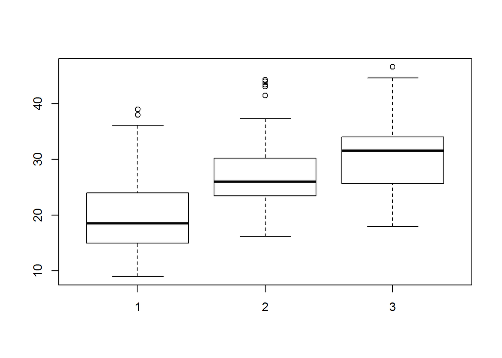

```r
boxplot(auto$mpg~auto$origin)
```

Japanese cars have higher mpg.

### Excercise 10a

```r
library(MASS)
boston = Boston
attach(boston)
names(boston)
```

```
##  [1] "crim"    "zn"      "indus"   "chas"    "nox"     "rm"      "age"
##  [8] "dis"     "rad"     "tax"     "ptratio" "black"   "lstat"   "medv"
```

```r
summary(boston)
```

```
##       crim                zn             indus            chas
##  Min.   : 0.00632   Min.   :  0.00   Min.   : 0.46   Min.   :0.00000
##  1st Qu.: 0.08204   1st Qu.:  0.00   1st Qu.: 5.19   1st Qu.:0.00000
##  Median : 0.25651   Median :  0.00   Median : 9.69   Median :0.00000
##  Mean   : 3.61352   Mean   : 11.36   Mean   :11.14   Mean   :0.06917
##  3rd Qu.: 3.67708   3rd Qu.: 12.50   3rd Qu.:18.10   3rd Qu.:0.00000
##  Max.   :88.97620   Max.   :100.00   Max.   :27.74   Max.   :1.00000
##       nox               rm             age              dis
##  Min.   :0.3850   Min.   :3.561   Min.   :  2.90   Min.   : 1.130
##  1st Qu.:0.4490   1st Qu.:5.886   1st Qu.: 45.02   1st Qu.: 2.100
##  Median :0.5380   Median :6.208   Median : 77.50   Median : 3.207
##  Mean   :0.5547   Mean   :6.285   Mean   : 68.57   Mean   : 3.795
##  3rd Qu.:0.6240   3rd Qu.:6.623   3rd Qu.: 94.08   3rd Qu.: 5.188
##  Max.   :0.8710   Max.   :8.780   Max.   :100.00   Max.   :12.127
##       rad              tax           ptratio          black
##  Min.   : 1.000   Min.   :187.0   Min.   :12.60   Min.   :  0.32
##  1st Qu.: 4.000   1st Qu.:279.0   1st Qu.:17.40   1st Qu.:375.38
##  Median : 5.000   Median :330.0   Median :19.05   Median :391.44
##  Mean   : 9.549   Mean   :408.2   Mean   :18.46   Mean   :356.67
##  3rd Qu.:24.000   3rd Qu.:666.0   3rd Qu.:20.20   3rd Qu.:396.23
##  Max.   :24.000   Max.   :711.0   Max.   :22.00   Max.   :396.90
##      lstat            medv
##  Min.   : 1.73   Min.   : 5.00
##  1st Qu.: 6.95   1st Qu.:17.02
##  Median :11.36   Median :21.20
##  Mean   :12.65   Mean   :22.53
##  3rd Qu.:16.95   3rd Qu.:25.00
##  Max.   :37.97   Max.   :50.00
```

```r
nrow(boston)
```

```
## [1] 506
```

### Excercise 10b

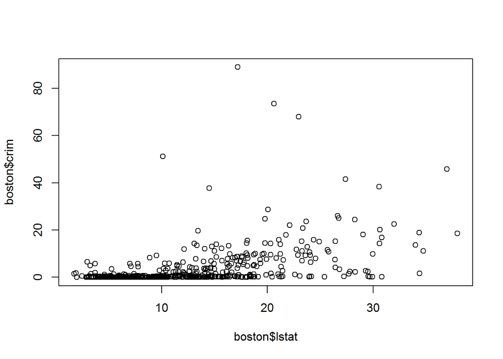

```r
plot(boston$lstat, boston$crim)
```

Crime rate is higher in lower status population

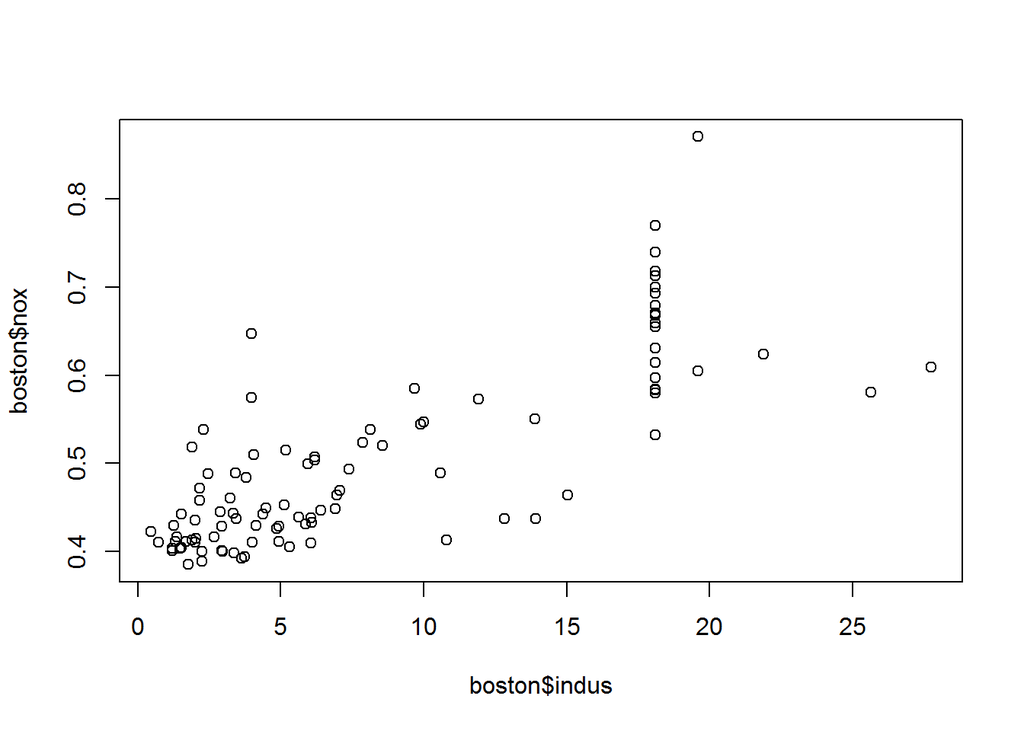

```r
plot(boston$indus, boston$nox)
```

Proportion of non-retail business acres per town indicate higher nitrogen oxides concentration (parts per 10 million).

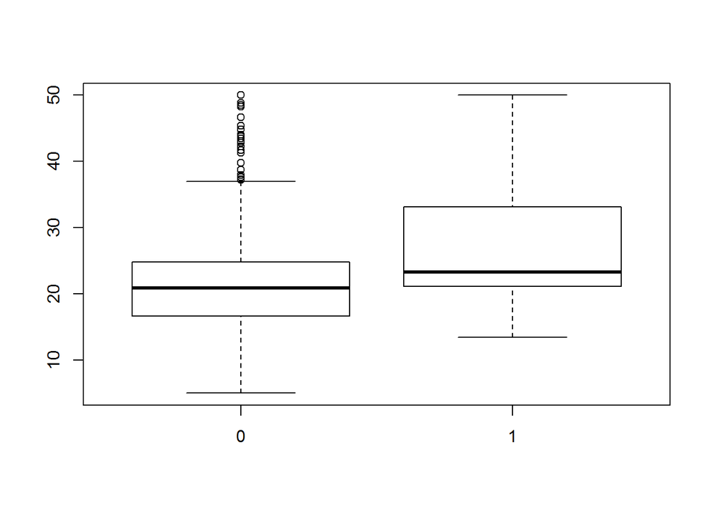

```r
boxplot(medv~chas)
```

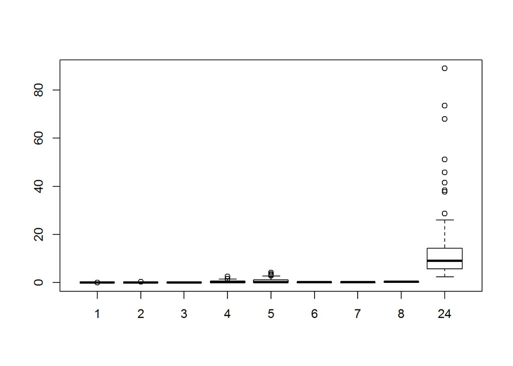

```r
par(mfrow=c(1, 1))
boxplot(crim~rad) # crim rate is high in areas near radial highways
```

Properties near river has higher values

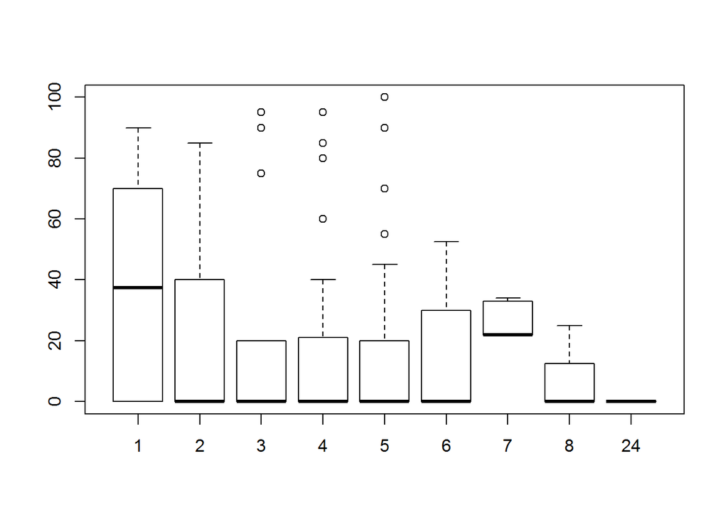

```r
boxplot(zn~rad)
```

Proportion of residential land zoned for lots over 25,000 sq.ft. is high in suburb.

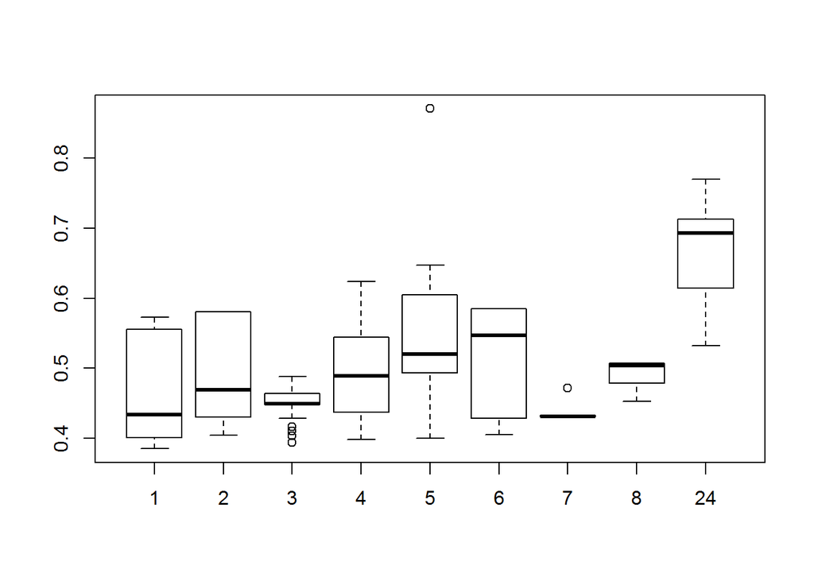

```r
boxplot(nox~rad)
```

Nitrogen oxides concentration is high in areas near radial highways.

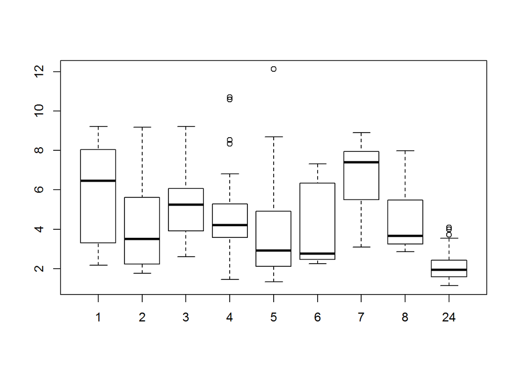

```r
boxplot(dis~rad)
```

Distances to employment centers are smallest in areas near radial highways.

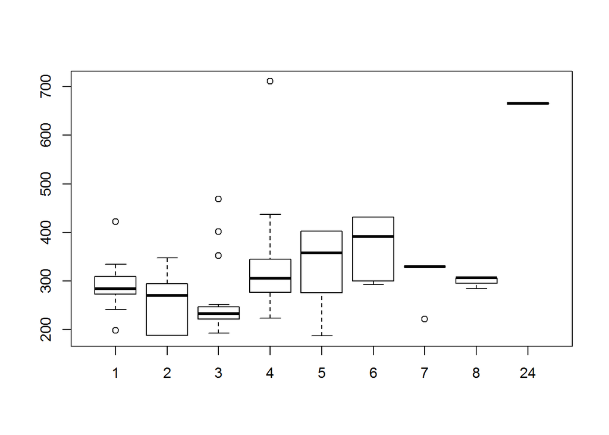

```r
boxplot(tax~rad)
```

Tax value is high for properties in areas near radial highways.

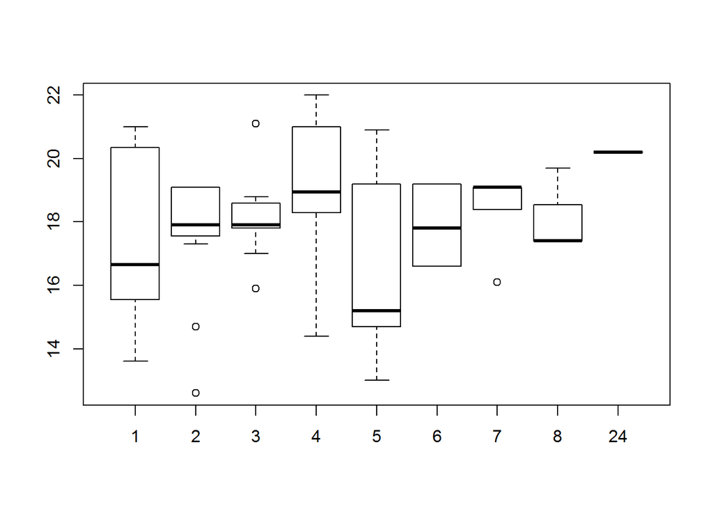

```r
boxplot(ptratio~rad)
```

Ratio of pupil teacher is low in suburb.

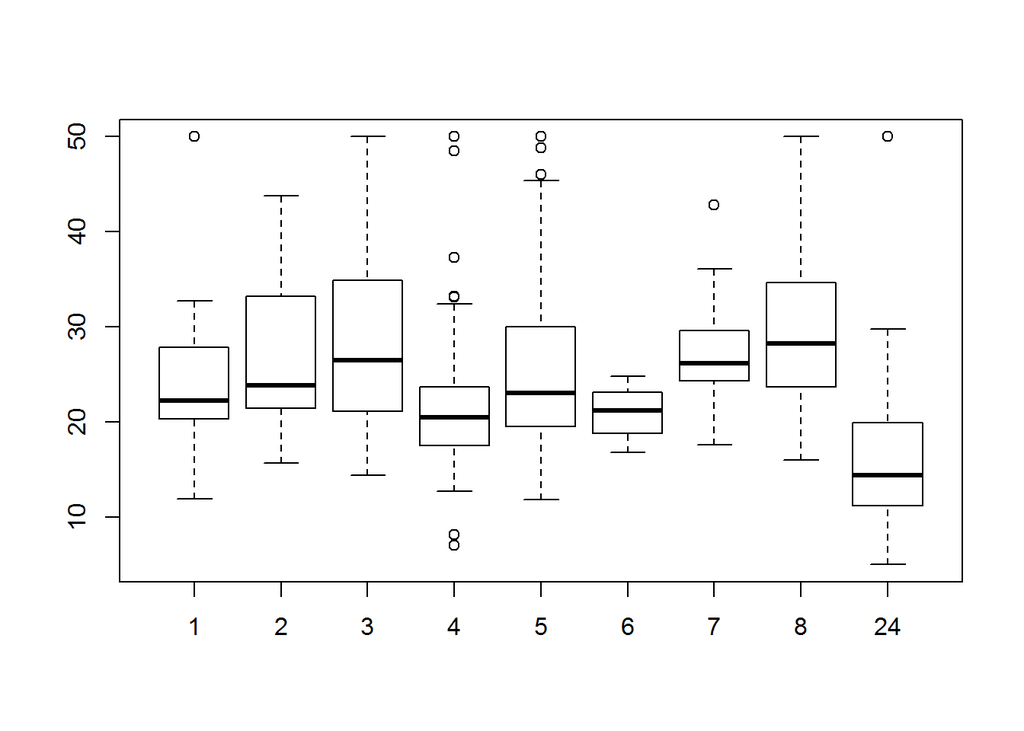

```r
boxplot(medv~rad)
```

Median value of owner-occupied homes is low in areas near radial highways.

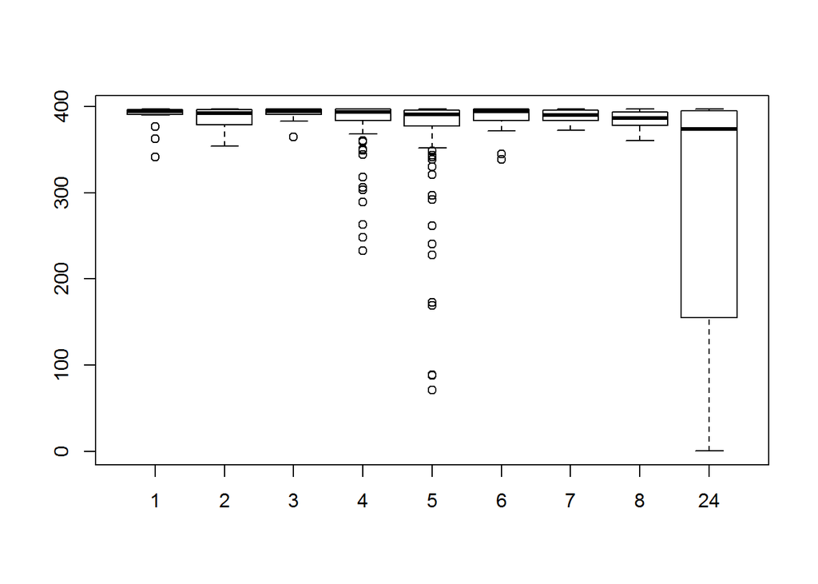

```r
boxplot(black~rad)
```

Proportion of blacks varies greatly in areas near radial highways.

### Excercise 10c

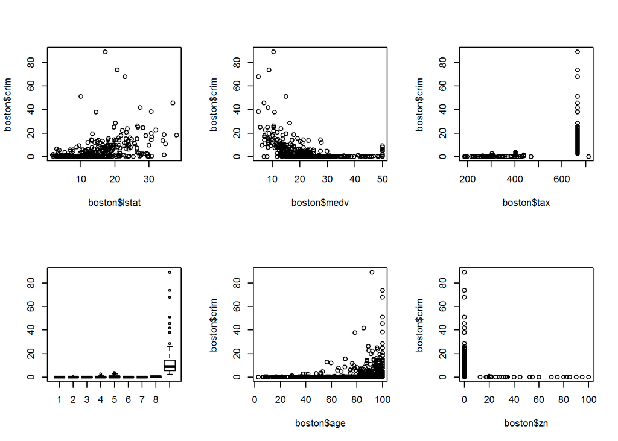

```r
par(mfrow=c(2,3))
plot(boston$lstat, boston$crim)
plot(boston$medv, boston$crim)
plot(boston$tax, boston$crim)
boxplot(crim~rad)
plot(boston$age, boston$crim)
plot(boston$zn, boston$crim)
```

```r
par(mfrow=c(1,1))
```

### Excercise 10d

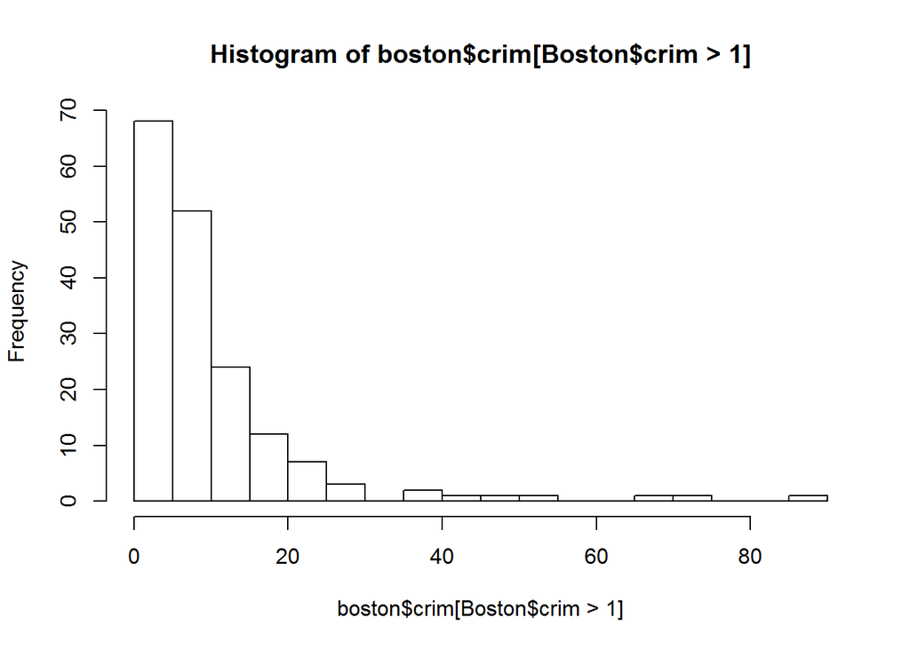

```r
hist(boston$crim[Boston$crim>1], breaks=25)
```

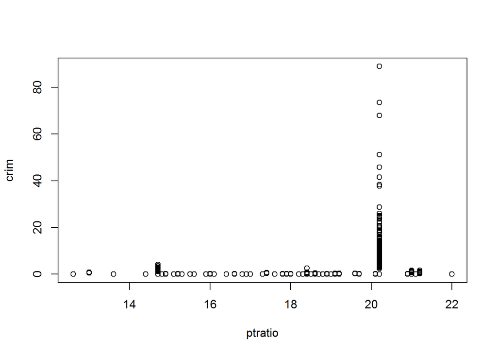

```r
plot(ptratio, crim) # Higher pupil:teacher ratio, more crime
```